# Integrative_Analysis_RNA_chip

Alizée LANON

2024-06-27

### Retrieving the data and keep only the 5000 genes via their value of logFold change during Differential Analysis

```r
library(mixOmics)
# Loading the data
RNA_counts <- read.csv("../../../Glioma/Stepniak/Integrative_Analysis/Data/counts_RNA_Stepniak_norm.csv", header = TRUE, sep = " ")
RNA_genes <- read.csv("../../../Glioma/Stepniak/Integrative_Analysis/Data/5000_genes_logFC_RNA_Stepniak.csv", header = TRUE, sep = " ")

H3K27ac_counts <- read.csv("../../../Glioma/Stepniak/Integrative_Analysis/Data/counts_ChIP_H3K27ac_Stepniak_norm.csv", header = TRUE, sep = " ")
H3K27ac_loci <- read.csv("../../../Glioma/Stepniak/Integrative_Analysis/Data/5000_peaks_logFC_H3K27ac_Stepniak.csv", header = TRUE, sep = " ")

H3K27me3_counts <- read.csv("../../../Glioma/Stepniak/Integrative_Analysis/Data/counts_ChIP_H3K27me3_Stepniak_norm.csv", header = TRUE, sep = " ")
H3K27me3_loci <- read.csv("../../../Glioma/Stepniak/Integrative_Analysis/Data/5000_peaks_logFC_H3K27me3_Stepniak.csv", header = TRUE, sep = " ")

H3K4me3_counts <- read.csv("../../../Glioma/Stepniak/Integrative_Analysis/Data/counts_ChIP_H3K4me3_Stepniak_norm.csv", header = TRUE, sep = " ")
H3K4me3_loci <- read.csv("../../../Glioma/Stepniak/Integrative_Analysis/Data/5000_peaks_logFC_H3K4me3_Stepniak.csv", header = TRUE, sep = " ")

# Tresholding RNAseq on 5000 genes with biggest lofFC (2500neg and 2500pos)
rna_counts_5000 <- RNA_counts[row.names(RNA_counts) %in% RNA_genes$gene_id , ]
#list_genes <- intersect(row.names(rna_counts_5000),RNA_genes$gene_id)
#write.table(H3K27ac_counts_5000, "Data/H3K27ac_counts_5000.csv", row.names = TRUE )
H3K27ac_counts_5000 <- read.csv("../../../Glioma/Stepniak/Integrative_Analysis/Data/H3K27ac_counts_5000.csv", header = TRUE, sep = " ")
H3K27me3_counts_5000 <- H3K27me3_counts[row.names(H3K27me3_counts) %in% H3K27me3_loci$genes , ]
H3K4me3_counts_5000 <- H3K4me3_counts[row.names(H3K4me3_counts) %in% H3K4me3_loci$genes , ]
H3K27ac_counts_5000 <- H3K27ac_counts[row.names(H3K27ac_counts) %in% H3K27ac_loci$genes , ]
```

### Replacing gene ID by gene names in RNAseq data

```r
library(ChIPpeakAnno)
library(EnsDb.Hsapiens.v86)
library(org.Hs.eg.db)
library(biomaRt)
library(dplyr)

####### RNAseq dataset ###########################################################################################
# Associating ID and interavls to gene names
indices <- match(rownames(rna_counts_5000), RNA_genes$gene_id)

# Add a new column of the gene names with the matching gene id
rna_counts_5000$gene_name <- RNA_genes$gene_name[indices]

# Reorganising the columns order
rna_counts_5000 <- rna_counts_5000[, c("gene_name", "DA01", "DA05", "DA06", "DA02", "DA03", "DA04")]

rna_counts_5000$gene_name <- ifelse(is.na(rna_counts_5000$gene_name), rownames(rna_counts_5000), rna_counts_5000$gene_name)

rna_counts_5000$gene_name <- make.names(rna_counts_5000$gene_name, unique = TRUE)
row.names(rna_counts_5000) <- rna_counts_5000$gene_name
rna_counts_5000 <- rna_counts_5000[,c(2:7)]
```

### Replacing intervals number by gene names in ChIPseq datasets H3K4me3

To perform this, the same method as in the ChIPseq analysis was performed with the ChIPpeakAnno package. After, the new object has to be built to be compatible with the function that builds the model. This was done also for the 2 other Histon marks H3K27me3 and H3K27ac.

```r
####### H3K4me3 dataset ###########################################################################################

h3k4me3_raw_counts <- read.delim(file = "../../../Glioma/Stepniak/ChiPseq/Count_matrix/H3K4me3.consensus_peaks.featureCounts.txt", header = TRUE, sep = "\t")

h3k4me3_raw_counts_info <- h3k4me3_raw_counts[,c(1,2,3,4,5)]
h3k4me3_raw_counts_info <- h3k4me3_raw_counts_info[h3k4me3_raw_counts_info$Geneid %in% H3K4me3_loci$genes,]

gr_h3k4me3 <- GRanges(
    seqnames = Rle(h3k4me3_raw_counts_info$Chr),
    ranges = IRanges(start = h3k4me3_raw_counts_info$Start, end = h3k4me3_raw_counts_info$End),
    strand = Rle(strand(h3k4me3_raw_counts_info$Strand)))

mcols(gr_h3k4me3) <- h3k4me3_raw_counts_info$Geneid

ensembl_hs86_transcript <- transcripts(EnsDb.Hsapiens.v86)

h3k4me3_macs_peaks <- annotatePeakInBatch(gr_h3k4me3,
                                         AnnotationData = ensembl_hs86_transcript)

mart <- useMart(biomart = "ENSEMBL_MART_ENSEMBL",
                dataset = "hsapiens_gene_ensembl")

macs_peak_ensembl_h3k4me3 <- addGeneIDs(annotatedPeak = h3k4me3_macs_peaks,
                                mart = mart,
                                feature_id_type = "ensembl_transcript_id",
                                IDs2Add = "hgnc_symbol")

macs_peak_ensembl_h3k4me3 <- as.data.frame(macs_peak_ensembl_h3k4me3)
# Group by peak ID and select the first gene name
peak_annotation_single_gene_h3K4me3 <- distinct(macs_peak_ensembl_h3k4me3, macs_peak_ensembl_h3k4me3$X, macs_peak_ensembl_h3k4me3$hgnc_symbol)
row.names(peak_annotation_single_gene_h3K4me3) <- NULL
peak_annotation_single_gene_h3K4me3 <- as.data.frame(peak_annotation_single_gene_h3K4me3)

# Replacing missing value by NA
peak_annotation_single_gene_h3K4me3[peak_annotation_single_gene_h3K4me3 == ""] <- NA
# Replacing NA by interval number
peak_annotation_single_gene_h3K4me3$`macs_peak_ensembl_h3k4me3$hgnc_symbol` <- ifelse(is.na(peak_annotation_single_gene_h3K4me3$`macs_peak_ensembl_h3k4me3$hgnc_symbol`), peak_annotation_single_gene_h3K4me3$`macs_peak_ensembl_h3k4me3$X`, peak_annotation_single_gene_h3K4me3$`macs_peak_ensembl_h3k4me3$hgnc_symbol`)

peak_annotation_single_gene_h3K4me3 <- distinct(peak_annotation_single_gene_h3K4me3, peak_annotation_single_gene_h3K4me3$`macs_peak_ensembl_h3k4me3$X`, .keep_all = TRUE)

peak_annotation_single_gene_h3K4me3 <- peak_annotation_single_gene_h3K4me3 %>%
  distinct(peak_annotation_single_gene_h3K4me3$`macs_peak_ensembl_h3k4me3$X`, .keep_all = TRUE)

peak_annotation_single_gene_h3K4me3 <- peak_annotation_single_gene_h3K4me3[,c(1,2)]

# Matching with the first dataset
indices_h3k4me3 <- match(rownames(H3K4me3_counts_5000), peak_annotation_single_gene_h3K4me3$`macs_peak_ensembl_h3k4me3$X`)
H3K4me3_counts_5000$gene_name <- peak_annotation_single_gene_h3K4me3$`macs_peak_ensembl_h3k4me3$hgnc_symbol`[indices_h3k4me3]

# Reorganising the columns order
#H3K4me3_counts_5000 <- H3K4me3_counts_5000[, c("gene_name", "DA01", "DA05", "DA06", "DA02", "DA03", "DA04")]

merge_columns <- function(col1, col2) {
  merged_col <- ifelse(col1 == col2, col1, paste(col1, col2, sep = "__"))
  return(merged_col)
}

# Apply the function to the columns
H3K4me3_counts_5000$name <- merge_columns(H3K4me3_counts_5000$gene_name,row.names(H3K4me3_counts_5000))
H3K4me3_counts_5000 <- H3K4me3_counts_5000[, c("gene_name","name", "DA01", "DA05", "DA06", "DA02", "DA03", "DA04")]
row.names(H3K4me3_counts_5000) <- H3K4me3_counts_5000$name
H3K4me3_counts_5000 <- H3K4me3_counts_5000[,c(3:8)]
###################################################################################################################################################
```

### Replacing intervals number by gene names in ChIPseq datasets H3K27me3

```r
h3k27me3_raw_counts <- read.delim(file = "../../../Glioma/Stepniak/ChiPseq/Count_matrix/H3K27me3.consensus_peaks.featureCounts.txt", header = TRUE, sep = "\t")

h3k27me3_raw_counts_info <- h3k27me3_raw_counts[,c(1,2,3,4,5)]
h3k27me3_raw_counts_info <- h3k27me3_raw_counts_info[h3k27me3_raw_counts_info$Geneid %in% H3K27me3_loci$genes,]

gr_h3k27me3 <- GRanges(
    seqnames = Rle(h3k27me3_raw_counts_info$Chr),
    ranges = IRanges(start = h3k27me3_raw_counts_info$Start, end = h3k27me3_raw_counts_info$End),
    strand = Rle(strand(h3k27me3_raw_counts_info$Strand)))

mcols(gr_h3k27me3) <- h3k27me3_raw_counts_info$Geneid

ensembl_hs86_transcript <- transcripts(EnsDb.Hsapiens.v86)

h3k27me3_macs_peaks <- annotatePeakInBatch(gr_h3k27me3,
                                         AnnotationData = ensembl_hs86_transcript)

mart <- useMart(biomart = "ENSEMBL_MART_ENSEMBL",
                dataset = "hsapiens_gene_ensembl")

macs_peak_ensembl_h3k27me3 <- addGeneIDs(annotatedPeak = h3k27me3_macs_peaks,
                                mart = mart,
                                feature_id_type = "ensembl_transcript_id",
                                IDs2Add = "hgnc_symbol")

macs_peak_ensembl_h3k27me3 <- as.data.frame(macs_peak_ensembl_h3k27me3)
# Group by peak ID and select the first gene name
peak_annotation_single_gene_h3K27me3 <- distinct(macs_peak_ensembl_h3k27me3, macs_peak_ensembl_h3k27me3$X, macs_peak_ensembl_h3k27me3$hgnc_symbol)
row.names(peak_annotation_single_gene_h3K27me3) <- NULL
peak_annotation_single_gene_h3K27me3 <- as.data.frame(peak_annotation_single_gene_h3K27me3)

# Replacing missing value by NA
peak_annotation_single_gene_h3K27me3[peak_annotation_single_gene_h3K27me3 == ""] <- NA
# Replacing NA by interval number
peak_annotation_single_gene_h3K27me3$`macs_peak_ensembl_h3k27me3$hgnc_symbol` <- ifelse(is.na(peak_annotation_single_gene_h3K27me3$`macs_peak_ensembl_h3k27me3$hgnc_symbol`), peak_annotation_single_gene_h3K27me3$`macs_peak_ensembl_h3k27me3$X`, peak_annotation_single_gene_h3K27me3$`macs_peak_ensembl_h3k27me3$hgnc_symbol`)

peak_annotation_single_gene_h3K27me3 <- distinct(peak_annotation_single_gene_h3K27me3, peak_annotation_single_gene_h3K27me3$`macs_peak_ensembl_h3k27me3$X`, .keep_all = TRUE)

peak_annotation_single_gene_h3K27me3 <- peak_annotation_single_gene_h3K27me3 %>%
  distinct(peak_annotation_single_gene_h3K27me3$`macs_peak_ensembl_h3k27me3$X`, .keep_all = TRUE)

peak_annotation_single_gene_h3K27me3 <- peak_annotation_single_gene_h3K27me3[,c(1,2)]

# Matching with the first dataset
indices_h3k27me3 <- match(rownames(H3K27me3_counts_5000), peak_annotation_single_gene_h3K27me3$`macs_peak_ensembl_h3k27me3$X`)
H3K27me3_counts_5000$gene_name <- peak_annotation_single_gene_h3K27me3$`macs_peak_ensembl_h3k27me3$hgnc_symbol`[indices_h3k27me3]

# Reorganising the columns order
H3K27me3_counts_5000 <- H3K27me3_counts_5000[, c("gene_name", "DA01", "DA05", "DA06", "DA02", "DA03", "DA04")]
# Apply the function to the columns
H3K27me3_counts_5000$name <- merge_columns(H3K27me3_counts_5000$gene_name,row.names(H3K27me3_counts_5000))
H3K27me3_counts_5000 <- H3K27me3_counts_5000[, c("gene_name","name", "DA01", "DA05", "DA06", "DA02", "DA03", "DA04")]
row.names(H3K27me3_counts_5000) <- H3K27me3_counts_5000$name
H3K27me3_counts_5000 <- H3K27me3_counts_5000[,c(3:8)]

###################################################################################################################################################
```

### Replacing intervals number by gene names in ChIPseq datasets H3K27ac

```r
h3k27ac_raw_counts <- read.delim(file = "../../../Glioma/Stepniak/ChiPseq/Count_matrix/H3K27ac.consensus_peaks.featureCounts.txt", header = TRUE, sep = "\t")

#h3k27ac_raw_counts <- read.csv("Data/H3K27ac_counts_5000.csv", header = TRUE, sep = " ")
h3k27ac_raw_counts_info <- h3k27ac_raw_counts[,c(1,2,3,4,5)]
h3k27ac_raw_counts_info <- h3k27ac_raw_counts_info[h3k27ac_raw_counts_info$Geneid %in% H3K27ac_loci$genes,]

gr_h3k27ac <- GRanges(
    seqnames = Rle(h3k27ac_raw_counts_info$Chr),
    ranges = IRanges(start = h3k27ac_raw_counts_info$Start, end = h3k27ac_raw_counts_info$End),
    strand = Rle(strand(h3k27ac_raw_counts_info$Strand)))

mcols(gr_h3k27ac) <- h3k27ac_raw_counts_info$Geneid

ensembl_hs86_transcript <- transcripts(EnsDb.Hsapiens.v86)

h3k27ac_macs_peaks <- annotatePeakInBatch(gr_h3k27ac,
                                         AnnotationData = ensembl_hs86_transcript)

mart <- useMart(biomart = "ENSEMBL_MART_ENSEMBL",
                dataset = "hsapiens_gene_ensembl")

macs_peak_ensembl_h3k27ac <- addGeneIDs(annotatedPeak = h3k27ac_macs_peaks,
                                mart = mart,
                                feature_id_type = "ensembl_transcript_id",
                                IDs2Add = "hgnc_symbol")

macs_peak_ensembl_h3k27ac <- as.data.frame(macs_peak_ensembl_h3k27ac)
# Group by peak ID and select the first gene name
peak_annotation_single_gene_h3K27ac <- distinct(macs_peak_ensembl_h3k27ac, macs_peak_ensembl_h3k27ac$X, macs_peak_ensembl_h3k27ac$hgnc_symbol)
row.names(peak_annotation_single_gene_h3K27ac) <- NULL
peak_annotation_single_gene_h3K27ac <- as.data.frame(peak_annotation_single_gene_h3K27ac)

# Replacing missing value by NA
peak_annotation_single_gene_h3K27ac[peak_annotation_single_gene_h3K27ac == ""] <- NA
# Replacing NA by interval number
peak_annotation_single_gene_h3K27ac$`macs_peak_ensembl_h3k27ac$hgnc_symbol` <- ifelse(is.na(peak_annotation_single_gene_h3K27ac$`macs_peak_ensembl_h3k27ac$hgnc_symbol`), peak_annotation_single_gene_h3K27ac$`macs_peak_ensembl_h3k27ac$X`, peak_annotation_single_gene_h3K27ac$`macs_peak_ensembl_h3k27ac$hgnc_symbol`)

peak_annotation_single_gene_h3K27ac <- distinct(peak_annotation_single_gene_h3K27ac, peak_annotation_single_gene_h3K27ac$`macs_peak_ensembl_h3k27ac$X`, .keep_all = TRUE)

peak_annotation_single_gene_h3K27ac <- peak_annotation_single_gene_h3K27ac %>%
  distinct(peak_annotation_single_gene_h3K27ac$`macs_peak_ensembl_h3k27ac$X`, .keep_all = TRUE)

peak_annotation_single_gene_h3K27ac <- peak_annotation_single_gene_h3K27ac[,c(1,2)]

# Matching with the first dataset
indices_h3k27ac <- match(rownames(H3K27ac_counts_5000), peak_annotation_single_gene_h3K27ac$`macs_peak_ensembl_h3k27ac$X`)
H3K27ac_counts_5000$gene_name <- peak_annotation_single_gene_h3K27ac$`macs_peak_ensembl_h3k27ac$hgnc_symbol`[indices_h3k27ac]

# Reorganising the columns order
H3K27ac_counts_5000 <- H3K27ac_counts_5000[, c("gene_name", "DA01_H3K27ac", "DA05_M_H3K27ac", "DA06_H3K27ac", "DA02_H3K27ac", "DA03_H3K27ac", "DA04_H3K27ac")]

colnames(H3K27ac_counts_5000) <- c("gene_name", "DA01", "DA05", "DA06", "DA02", "DA03", "DA04")
# Apply the function to the columns
H3K27ac_counts_5000$name <- merge_columns(H3K27ac_counts_5000$gene_name,row.names(H3K27ac_counts_5000))
H3K27ac_counts_5000 <- H3K27ac_counts_5000[, c("gene_name","name", "DA01", "DA05", "DA06", "DA02", "DA03", "DA04")]
row.names(H3K27ac_counts_5000) <- H3K27ac_counts_5000$name
H3K27ac_counts_5000 <- H3K27ac_counts_5000[,c(3:8)]
###################################################################################################################################################
```

### Transposition of the previous dataset to build the input for the next analysis

```r
# Transpose the objects
rna_counts_5000 <- as.data.frame(t(rna_counts_5000))
H3K27ac_counts_5000 <- as.data.frame(t(H3K27ac_counts_5000))
H3K27me3_counts_5000 <- as.data.frame(t(H3K27me3_counts_5000))
H3K4me3_counts_5000 <- as.data.frame(t(H3K4me3_counts_5000))
```

### Creation of the objects for further analysis

```r
Y <- read.csv("pdata_DA_complete.csv", sep =";")
Y <- Y$Group
Y <- as.factor(Y)


data1 = list(RNAseq = rna_counts_5000,
            H3K4me3 = H3K4me3_counts_5000,
            H3K27me3 = H3K27me3_counts_5000,
            H3K27ac = H3K27ac_counts_5000)

data = list(RNAseq = data1$RNAseq,
            H3K4me3 = data1$H3K4me3,
            H3K27me3 = data1$H3K27me3,
            H3K27ac = data1$H3K27ac)
```

### Partial Least Squares

This is not the most important setp, it was to vizualize the correlation of each dataset 2 by 2

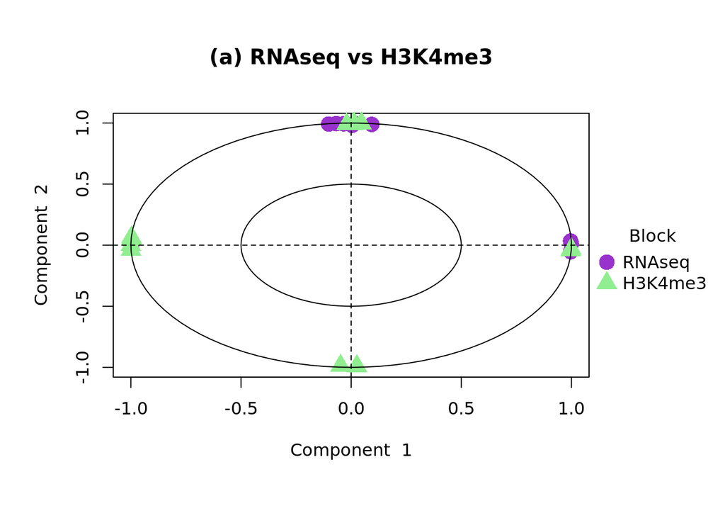

```r
list.keepX = c(6, 6) # select arbitrary values of features to keep
list.keepY = c(6, 6)

pls1 <- spls(data[["RNAseq"]], data[["H3K4me3"]],
             keepX = list.keepX, keepY = list.keepY)
pls2 <- spls(data[["RNAseq"]], data[["H3K27ac"]],
             keepX = list.keepX, keepY = list.keepY)
pls3 <- spls(data[["RNAseq"]], data[["H3K27me3"]],
             keepX = list.keepX, keepY = list.keepY)
pls4 <- spls(data[["H3K4me3"]], data[["H3K27me3"]],
             keepX = list.keepX, keepY = list.keepY)
pls5 <- spls(data[["H3K4me3"]], data[["H3K27ac"]],
             keepX = list.keepX, keepY = list.keepY)
pls6 <- spls(data[["H3K27ac"]], data[["H3K27me3"]],
             keepX = list.keepX, keepY = list.keepY)

#explained_variance_pls1 <- pls1$prop_expl_var
plotVar(pls1, cutoff = 0, title = "(a) RNAseq vs H3K4me3",
        legend = c("RNAseq", "H3K4me3"),
        var.names = FALSE, style = 'graphics',
        pch = c(16, 17), cex = c(2,2),
        col = c('darkorchid', 'lightgreen'))
```

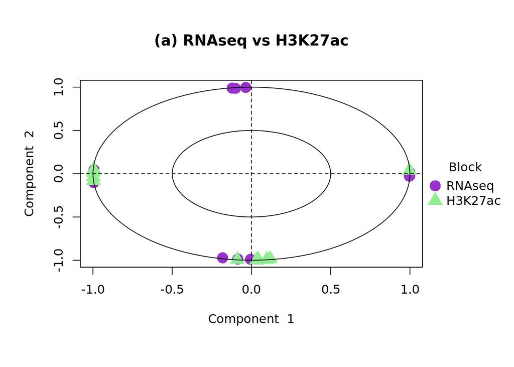

```r
plotVar(pls2, cutoff = 0, title = "(a) RNAseq vs H3K27ac",
        legend = c("RNAseq", "H3K27ac"),
        var.names = FALSE, style = 'graphics',
        pch = c(16, 17), cex = c(2,2),
        col = c('darkorchid', 'lightgreen'))
```

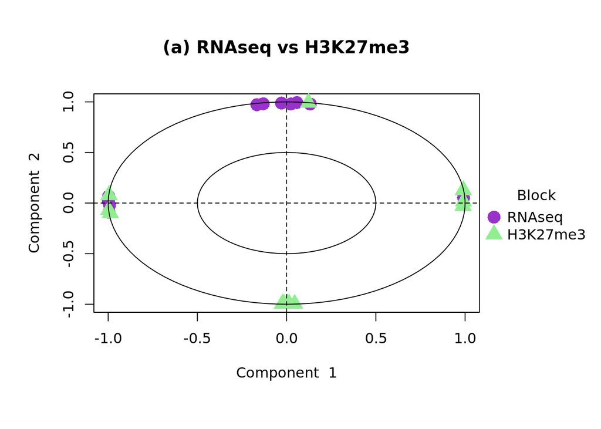

```r
plotVar(pls3, cutoff = 0, title = "(a) RNAseq vs H3K27me3",
        legend = c("RNAseq", "H3K27me3"),
        var.names = FALSE, style = 'graphics',
        pch = c(16, 17), cex = c(2,2),
        col = c('darkorchid', 'lightgreen'))
```

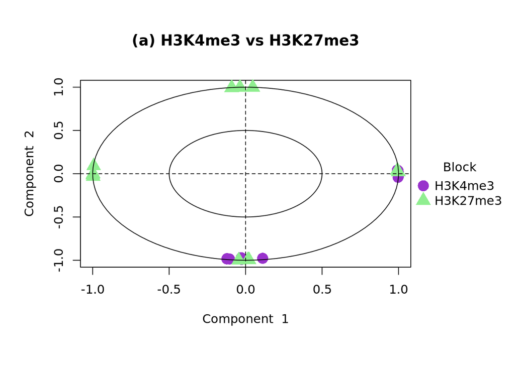

```r
plotVar(pls4, cutoff = 0, title = "(a) H3K4me3 vs H3K27me3",
        legend = c("H3K4me3", "H3K27me3"),
        var.names = FALSE, style = 'graphics',
        pch = c(16, 17), cex = c(2,2),
        col = c('darkorchid', 'lightgreen'))
```

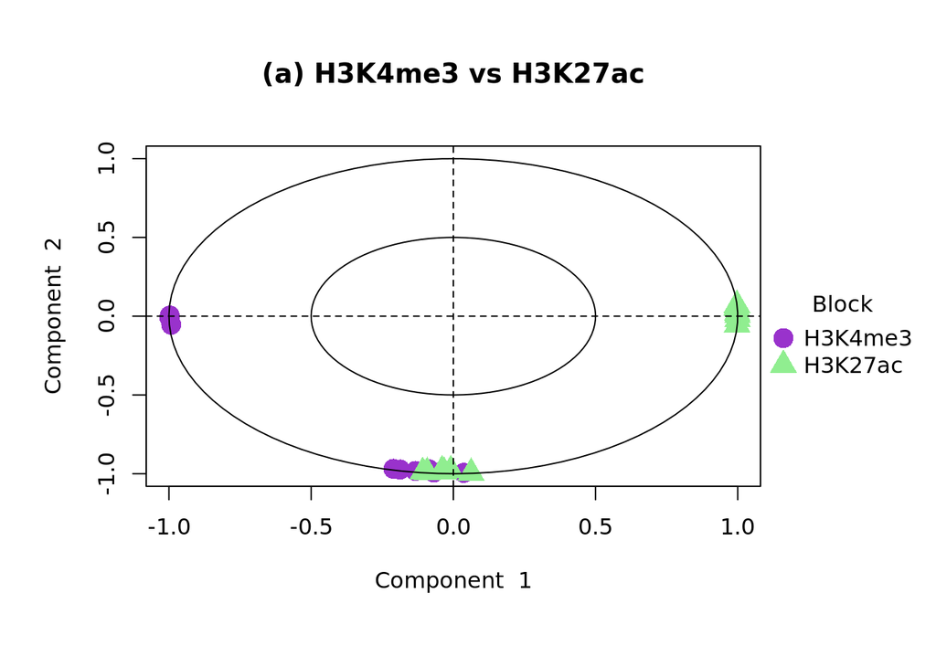

```r
plotVar(pls5, cutoff = 0, title = "(a) H3K4me3 vs H3K27ac",
        legend = c("H3K4me3", "H3K27ac"),
        var.names = FALSE, style = 'graphics',
        pch = c(16, 17), cex = c(2,2),
        col = c('darkorchid', 'lightgreen'))
```

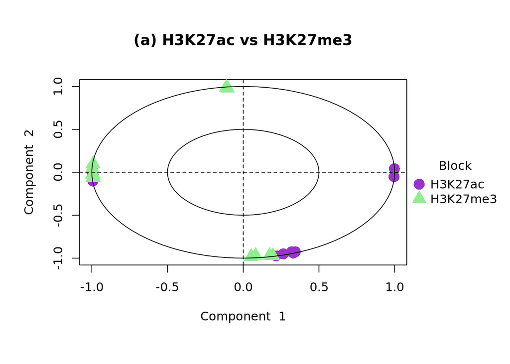

```r
plotVar(pls6, cutoff = 0, title = "(a) H3K27ac vs H3K27me3",
        legend = c("H3K27ac", "H3K27me3"),
        var.names = FALSE, style = 'graphics',
        pch = c(16, 17), cex = c(2,2),
        col = c('darkorchid', 'lightgreen'))
```

### Extracting correlation scores between block 2 by 2

```r
cor1 <- cor(pls1$variates$X, pls1$variates$Y)
cor2 <- cor(pls2$variates$X, pls2$variates$Y)
cor3 <- cor(pls3$variates$X, pls3$variates$Y)
cor4 <- cor(pls4$variates$X, pls4$variates$Y)
cor5 <- cor(pls5$variates$X, pls5$variates$Y)
cor6 <- cor(pls6$variates$X, pls6$variates$Y)
```

### Construction of the design matrix and the keepX object that allows the selection of the number of features to keep for each block and each component

```r
# for square matrix filled with 0.1s
design <- matrix(0.1, ncol = length(data), nrow = length(data),
                dimnames = list(names(data), names(data)))
diag(design) <- 0 # set diagonal to 0s
design
```

```
##          RNAseq H3K4me3 H3K27me3 H3K27ac
## RNAseq      0.0     0.1      0.1     0.1
## H3K4me3     0.1     0.0      0.1     0.1
## H3K27me3    0.1     0.1      0.0     0.1
## H3K27ac     0.1     0.1      0.1     0.0
```

```r
########### Construction of the keepX object

keep_X_1 <- list(
  RNAseq = c(1000, 1000),
  H3K4me3 = c(1000, 1000),
  H3K27me3 = c(1000, 1000),
  H3K27ac = c(1000, 1000)
)

keep_X_2 <- list(
  RNAseq = c(100, 100),
  H3K4me3 = c(100, 100),
  H3K27me3 = c(100, 100),
  H3K27ac = c(100, 100)
)

keep_X_3 <- list(
  RNAseq = c(50, 50),
  H3K4me3 = c(50, 50),
  H3K27me3 = c(50, 50),
  H3K27ac = c(50, 50)
)
```

### FINAL MODEL

We build the final model and extract the number of features of interest. The keep_X object can be chosen amongst the ones built previously or can be newly build. We then extracted the gene of interest and compared it to metabolism. See figure_integrative_analysis.R to have the lists of genes and intervals.

```r
#var <- selectVar(basic_diablo_model, comp = 1, block = 1)
final.diablo.model = block.splsda(X = data, Y = Y, ncomp = 2, design = design, keepX = keep_X_3)

rna_50_var <- selectVar(final.diablo.model, block = 'RNAseq', comp = 1)$RNAseq$name
h3k4me3_50_var <- selectVar(final.diablo.model, block = 'H3K4me3', comp = 1)$H3K4me3$name
h3k27me3_50_var <- selectVar(final.diablo.model, block = 'H3K27me3', comp = 1)$H3K27me3$name
h3k27ac_50_var <- selectVar(final.diablo.model, block = 'H3K27ac', comp = 1)$H3K27ac$name

genes_50_each <- c(rna_50_var, h3k4me3_50_var, h3k27me3_50_var, h3k27ac_50_var)
genes_50_each <- sub("__.*", "", genes_50_each)

metabo_genes_all <- read.table("../Differential_Analysis/Lists_genes/all_metabo.tsv", header = TRUE, sep = "\t")
metabo_genes <- metabo_genes_all$Gene_name

metabo <- intersect(metabo_genes,genes_50_each)
```

### PLOTS to vizualize the results

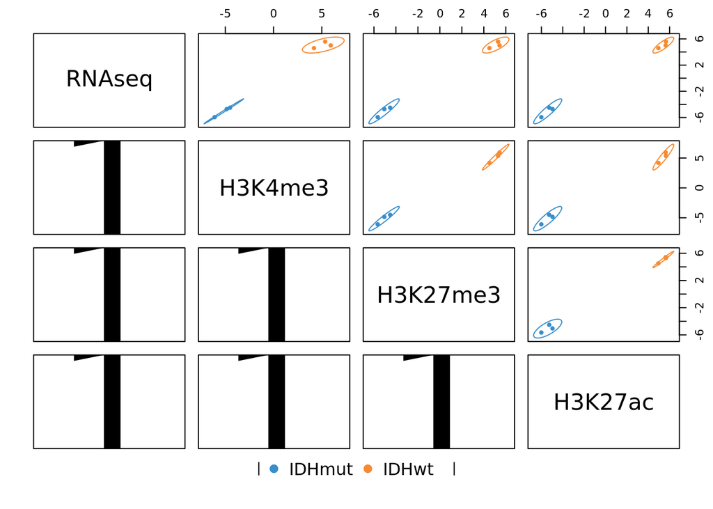

```r
plotDiablo(final.diablo.model, ncomp = 1)
```

## Plot of individuals

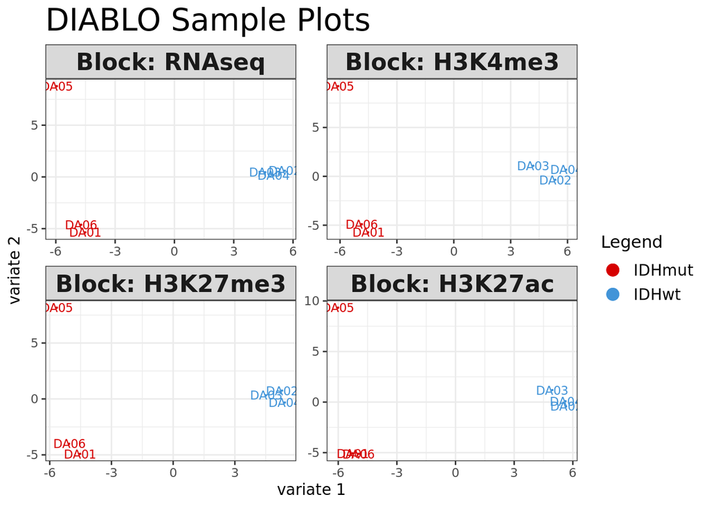

```r
plotIndiv(final.diablo.model, ind.names = TRUE, legend = TRUE,
          title = 'DIABLO Sample Plots',
          col.per.group = c("#D60000", "#4294D8"))
```

## Arrow plot

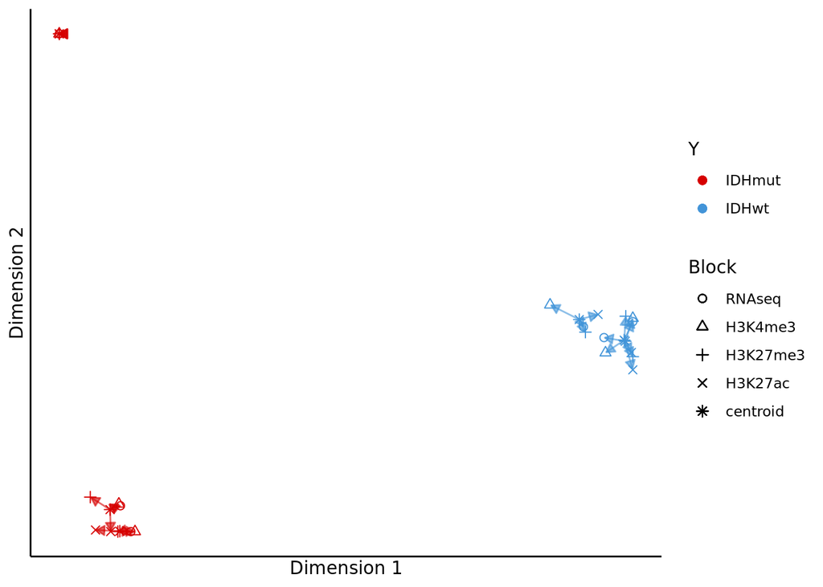

```r
plotArrow(final.diablo.model, ind.names = FALSE, legend = TRUE,
          title = 'DIABLO',
          col.per.group = c("#D60000", "#4294D8"))
```

## Correlation circle plot

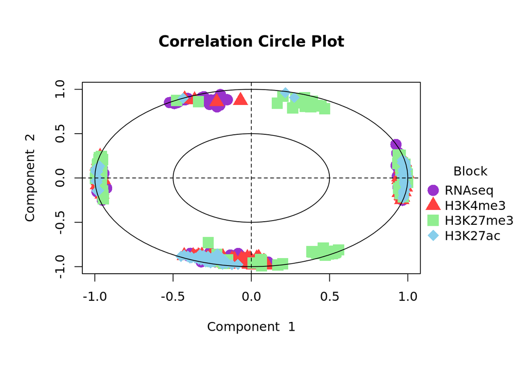

```r
plotVar(final.diablo.model, var.names = FALSE,
        style = 'graphics', legend = TRUE,
        pch = c(16, 17, 15,18), cex = c(2,2,2,2),
        col = c('darkorchid', 'brown1', 'lightgreen','skyblue'))
```

## Correlation plot

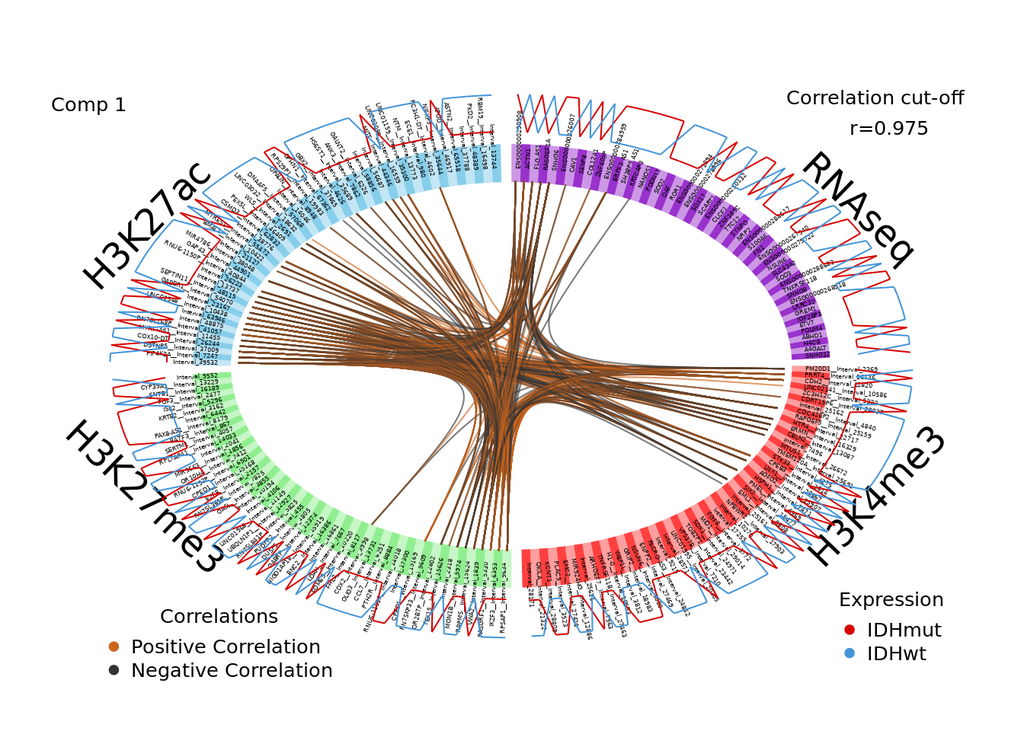

```r
circos_plot <- circosPlot(final.diablo.model, cutoff = 0.975, line = TRUE,
           color.blocks= c('darkorchid', 'brown1', 'lightgreen', 'skyblue'),
           color.cor = c("chocolate3","grey20"), size.labels = 1.5, comp =1,
           color.Y = c("#D60000", "#4294D8"))

# Open a PDF device
#pdf("circos_plot.pdf", width = 7, height = 5)  # Adjust dimensions as needed

# Call the plot function
circosPlot(final.diablo.model, cutoff = 0.975, line = TRUE,
           color.blocks= c('darkorchid', 'brown1', 'lightgreen', 'skyblue'),
           color.cor = c("chocolate3","grey20"), size.labels = 1.5, comp =1,
           color.Y = c("#D60000", "#4294D8")) # This function should contain plot commands
```

## Network

```r
network(final.diablo.model, blocks = c(1,2,3,4),
        color.node = c('darkorchid', 'brown1', 'lightgreen', 'skyblue'), cutoff = 0.95,
        save = "pdf",
        name.save = "network")
```

## Clustered Image Map

Go in figure_integrative_analysis to perform it

```r
#sim <- cimDiablo(final.diablo.model, comp = 1)
```